# Tobit regression

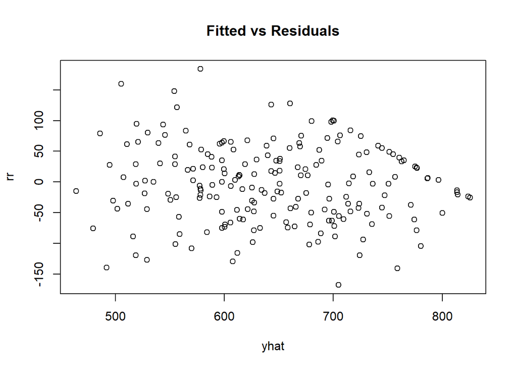

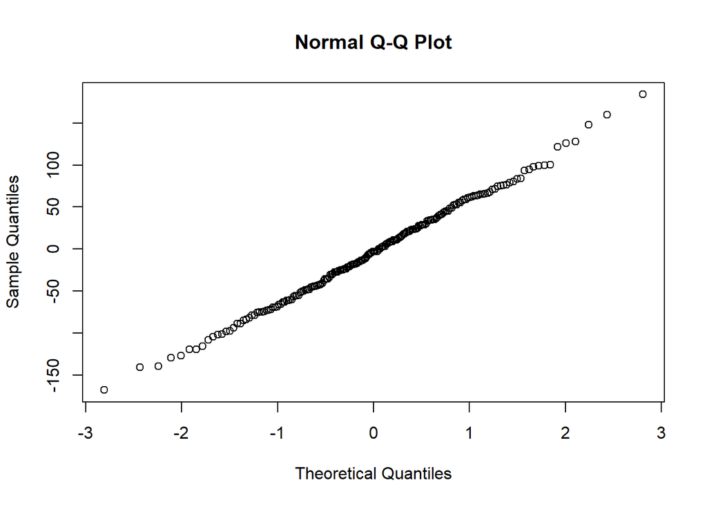

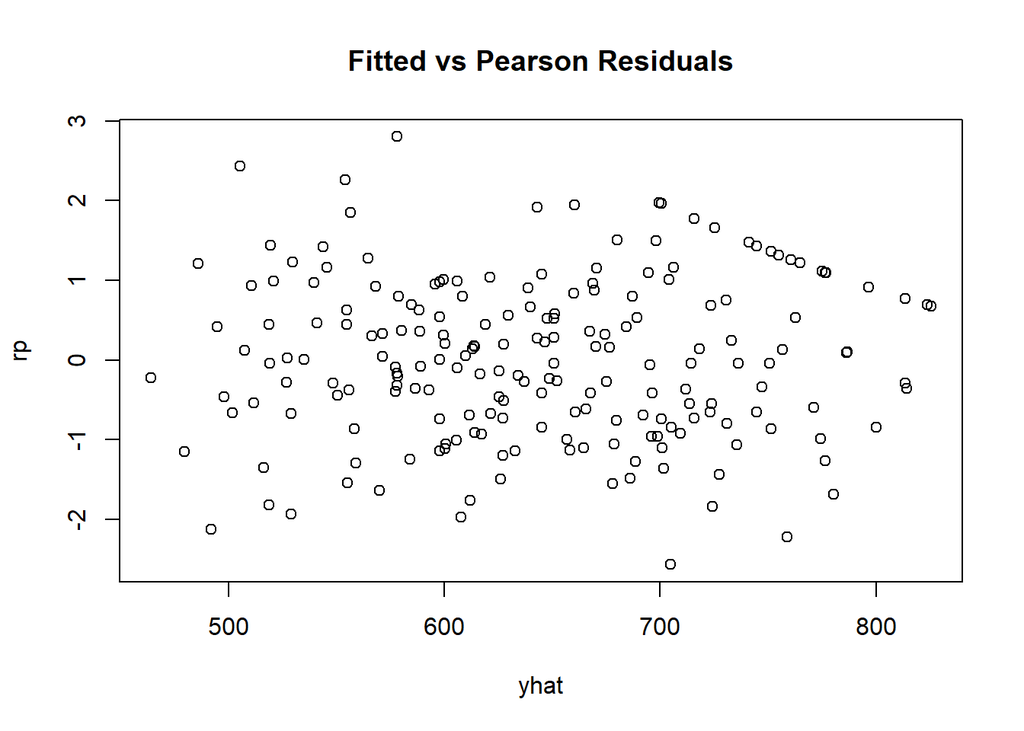

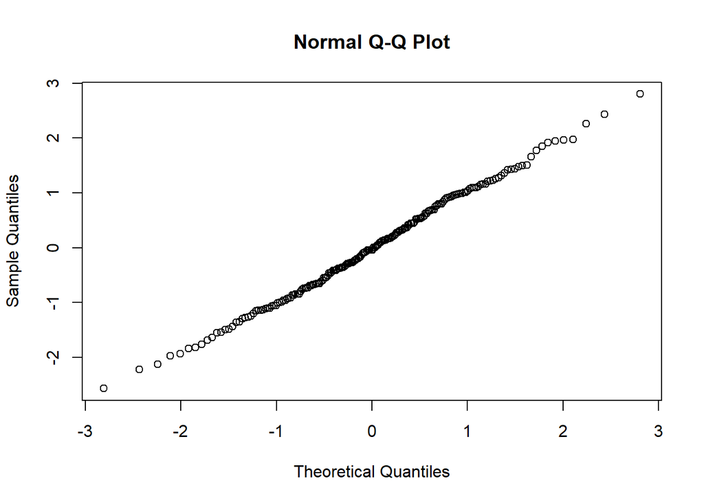

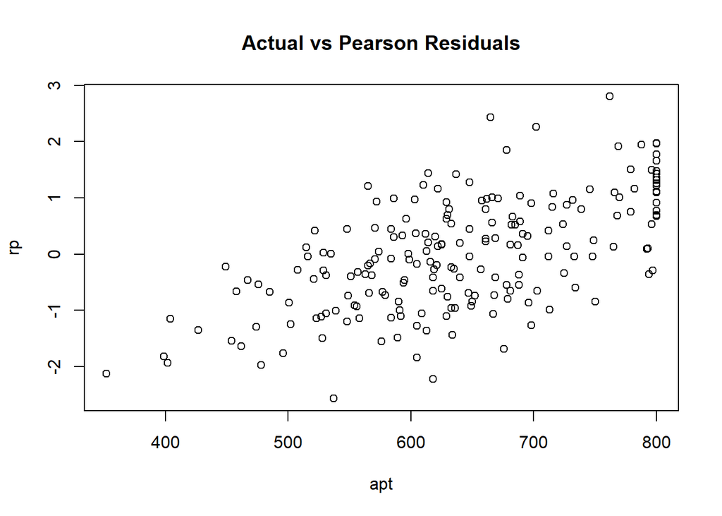

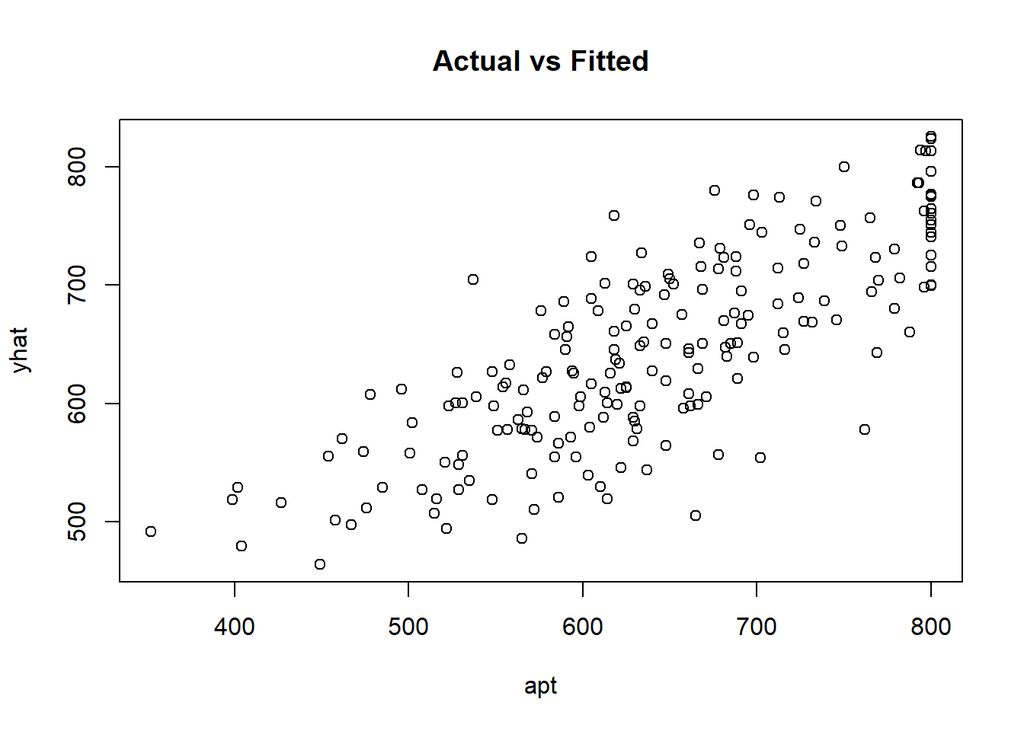

```r
with(dat, {
    plot(yhat, rr, main = "Fitted vs Residuals")
    qqnorm(rr)
    plot(yhat, rp, main = "Fitted vs Pearson Residuals")
    qqnorm(rp)
    plot(apt, rp, main = "Actual vs Pearson Residuals")
    plot(apt, yhat, main = "Actual vs Fitted")
})
```

The graph in the bottom right was the predicted, or fitted, values plotted against the actual. This can be particularly useful when comparing competing models. We can calculate the correlation between these two as well as the squared correlation, to get a sense of how accurate our model predicts the data and how much of the variance in the outcome is accounted for by the model.

```r
# correlation
(r <- with(dat, cor(yhat, apt)))
```

```
## [1] 0.7824708
```

```r
## [1] 0.7825
# variance accounted for
r^2
```

```
## [1] 0.6122606
```

```r
## [1] 0.6123
```

The correlation between the predicted and observed values of apt is 0.7825. If we square this value, we get the multiple squared correlation, this indicates predicted values share 61.23% of their variance with apt.

#### References

Long, J. S. 1997. Regression Models for Categorical and Limited Dependent Variables. Thousand Oaks, CA: Sage Publications.

McDonald, J. F. and Moffitt, R. A. 1980. The Uses of Tobit Analysis. The Review of Economics and Statistics Vol 62(2): 318-321.

Tobin, J. 1958. Estimation of relationships for limited dependent variables. Econometrica 26: 24-36.